# Risk Factor Analysis

## Outcome Variable

**Outcome Variable:** ever_swasted

## Predictor Variables

**Intervention Variable:** mage

**Adjustment Set:**

unadjusted

## Stratifying Variables

The analysis was stratified on these variable(s):

- agecat
- studyid
- country

## Data Summary

| agecat | studyid | country | mage | ever_swasted | n_cell | n |
| --- | --- | --- | --- | --- | --- | --- |
| 0-24 months | CMC-V-BCS-2002 | INDIA | [20-30) | 0 | 222 | 373 |
| 0-24 months | CMC-V-BCS-2002 | INDIA | [20-30) | 1 | 74 | 373 |
| 0-24 months | CMC-V-BCS-2002 | INDIA | <20 | 0 | 27 | 373 |
| 0-24 months | CMC-V-BCS-2002 | INDIA | <20 | 1 | 7 | 373 |
| 0-24 months | CMC-V-BCS-2002 | INDIA | >=30 | 0 | 32 | 373 |
| 0-24 months | CMC-V-BCS-2002 | INDIA | >=30 | 1 | 11 | 373 |
| 0-24 months | COHORTS | GUATEMALA | [20-30) | 0 | 608 | 1341 |
| 0-24 months | COHORTS | GUATEMALA | [20-30) | 1 | 47 | 1341 |
| 0-24 months | COHORTS | GUATEMALA | <20 | 0 | 180 | 1341 |
| 0-24 months | COHORTS | GUATEMALA | <20 | 1 | 16 | 1341 |
| 0-24 months | COHORTS | GUATEMALA | >=30 | 0 | 456 | 1341 |
| 0-24 months | COHORTS | GUATEMALA | >=30 | 1 | 34 | 1341 |
| 0-24 months | COHORTS | INDIA | [20-30) | 0 | 3245 | 5305 |
| 0-24 months | COHORTS | INDIA | [20-30) | 1 | 352 | 5305 |
| 0-24 months | COHORTS | INDIA | <20 | 0 | 384 | 5305 |
| 0-24 months | COHORTS | INDIA | <20 | 1 | 42 | 5305 |
| 0-24 months | COHORTS | INDIA | >=30 | 0 | 1129 | 5305 |
| 0-24 months | COHORTS | INDIA | >=30 | 1 | 153 | 5305 |
| 0-24 months | COHORTS | PHILIPPINES | [20-30) | 0 | 1596 | 3045 |
| 0-24 months | COHORTS | PHILIPPINES | [20-30) | 1 | 224 | 3045 |
| 0-24 months | COHORTS | PHILIPPINES | <20 | 0 | 326 | 3045 |
| 0-24 months | COHORTS | PHILIPPINES | <20 | 1 | 51 | 3045 |
| 0-24 months | COHORTS | PHILIPPINES | >=30 | 0 | 741 | 3045 |
| 0-24 months | COHORTS | PHILIPPINES | >=30 | 1 | 107 | 3045 |
| 0-24 months | EE | PAKISTAN | [20-30) | 0 | 134 | 377 |
| 0-24 months | EE | PAKISTAN | [20-30) | 1 | 28 | 377 |
| 0-24 months | EE | PAKISTAN | <20 | 0 | 1 | 377 |
| 0-24 months | EE | PAKISTAN | <20 | 1 | 0 | 377 |
| 0-24 months | EE | PAKISTAN | >=30 | 0 | 163 | 377 |
| 0-24 months | EE | PAKISTAN | >=30 | 1 | 51 | 377 |

[output cut: 432 more lines]

The following strata were considered:

- agecat: 0-24 months, studyid: CMC-V-BCS-2002, country: INDIA
- agecat: 0-24 months, studyid: COHORTS, country: GUATEMALA
- agecat: 0-24 months, studyid: COHORTS, country: INDIA
- agecat: 0-24 months, studyid: COHORTS, country: PHILIPPINES
- agecat: 0-24 months, studyid: EE, country: PAKISTAN
- agecat: 0-24 months, studyid: GMS-Nepal, country: NEPAL
- agecat: 0-24 months, studyid: Guatemala BSC, country: GUATEMALA
- agecat: 0-24 months, studyid: iLiNS-Zinc, country: BURKINA FASO
- agecat: 0-24 months, studyid: IRC, country: INDIA
- agecat: 0-24 months, studyid: Keneba, country: GAMBIA
- agecat: 0-24 months, studyid: LCNI-5, country: MALAWI
- agecat: 0-24 months, studyid: MAL-ED, country: BANGLADESH
- agecat: 0-24 months, studyid: MAL-ED, country: BRAZIL
- agecat: 0-24 months, studyid: MAL-ED, country: INDIA
- agecat: 0-24 months, studyid: MAL-ED, country: NEPAL
- agecat: 0-24 months, studyid: MAL-ED, country: PERU
- agecat: 0-24 months, studyid: MAL-ED, country: SOUTH AFRICA
- agecat: 0-24 months, studyid: MAL-ED, country: TANZANIA, UNITED REPUBLIC OF
- agecat: 0-24 months, studyid: NIH-Birth, country: BANGLADESH
- agecat: 0-24 months, studyid: NIH-Crypto, country: BANGLADESH
- agecat: 0-24 months, studyid: PROBIT, country: BELARUS
- agecat: 0-24 months, studyid: PROVIDE, country: BANGLADESH
- agecat: 0-24 months, studyid: SAS-CompFeed, country: INDIA
- agecat: 0-24 months, studyid: SAS-FoodSuppl, country: INDIA
- agecat: 0-24 months, studyid: TanzaniaChild2, country: TANZANIA, UNITED REPUBLIC OF
- agecat: 0-24 months, studyid: ZVITAMBO, country: ZIMBABWE
- agecat: 0-6 months, studyid: CMC-V-BCS-2002, country: INDIA
- agecat: 0-6 months, studyid: COHORTS, country: GUATEMALA
- agecat: 0-6 months, studyid: COHORTS, country: INDIA
- agecat: 0-6 months, studyid: COHORTS, country: PHILIPPINES
- agecat: 0-6 months, studyid: EE, country: PAKISTAN
- agecat: 0-6 months, studyid: GMS-Nepal, country: NEPAL
- agecat: 0-6 months, studyid: Guatemala BSC, country: GUATEMALA
- agecat: 0-6 months, studyid: IRC, country: INDIA
- agecat: 0-6 months, studyid: Keneba, country: GAMBIA
- agecat: 0-6 months, studyid: LCNI-5, country: MALAWI
- agecat: 0-6 months, studyid: MAL-ED, country: BANGLADESH
- agecat: 0-6 months, studyid: MAL-ED, country: BRAZIL
- agecat: 0-6 months, studyid: MAL-ED, country: INDIA
- agecat: 0-6 months, studyid: MAL-ED, country: NEPAL
- agecat: 0-6 months, studyid: MAL-ED, country: PERU
- agecat: 0-6 months, studyid: MAL-ED, country: SOUTH AFRICA
- agecat: 0-6 months, studyid: MAL-ED, country: TANZANIA, UNITED REPUBLIC OF
- agecat: 0-6 months, studyid: NIH-Birth, country: BANGLADESH
- agecat: 0-6 months, studyid: NIH-Crypto, country: BANGLADESH
- agecat: 0-6 months, studyid: PROBIT, country: BELARUS
- agecat: 0-6 months, studyid: PROVIDE, country: BANGLADESH
- agecat: 0-6 months, studyid: SAS-CompFeed, country: INDIA
- agecat: 0-6 months, studyid: SAS-FoodSuppl, country: INDIA
- agecat: 0-6 months, studyid: TanzaniaChild2, country: TANZANIA, UNITED REPUBLIC OF
- agecat: 0-6 months, studyid: ZVITAMBO, country: ZIMBABWE
- agecat: 6-24 months, studyid: CMC-V-BCS-2002, country: INDIA
- agecat: 6-24 months, studyid: COHORTS, country: GUATEMALA
- agecat: 6-24 months, studyid: COHORTS, country: INDIA
- agecat: 6-24 months, studyid: COHORTS, country: PHILIPPINES
- agecat: 6-24 months, studyid: EE, country: PAKISTAN
- agecat: 6-24 months, studyid: GMS-Nepal, country: NEPAL
- agecat: 6-24 months, studyid: Guatemala BSC, country: GUATEMALA
- agecat: 6-24 months, studyid: iLiNS-Zinc, country: BURKINA FASO
- agecat: 6-24 months, studyid: IRC, country: INDIA
- agecat: 6-24 months, studyid: Keneba, country: GAMBIA
- agecat: 6-24 months, studyid: LCNI-5, country: MALAWI
- agecat: 6-24 months, studyid: MAL-ED, country: BANGLADESH
- agecat: 6-24 months, studyid: MAL-ED, country: BRAZIL
- agecat: 6-24 months, studyid: MAL-ED, country: INDIA
- agecat: 6-24 months, studyid: MAL-ED, country: NEPAL
- agecat: 6-24 months, studyid: MAL-ED, country: PERU
- agecat: 6-24 months, studyid: MAL-ED, country: SOUTH AFRICA
- agecat: 6-24 months, studyid: MAL-ED, country: TANZANIA, UNITED REPUBLIC OF
- agecat: 6-24 months, studyid: NIH-Birth, country: BANGLADESH
- agecat: 6-24 months, studyid: NIH-Crypto, country: BANGLADESH
- agecat: 6-24 months, studyid: PROBIT, country: BELARUS
- agecat: 6-24 months, studyid: PROVIDE, country: BANGLADESH
- agecat: 6-24 months, studyid: SAS-CompFeed, country: INDIA
- agecat: 6-24 months, studyid: SAS-FoodSuppl, country: INDIA
- agecat: 6-24 months, studyid: TanzaniaChild2, country: TANZANIA, UNITED REPUBLIC OF
- agecat: 6-24 months, studyid: ZVITAMBO, country: ZIMBABWE

### Dropped Strata

Some strata were dropped due to rare outcomes:

- agecat: 0-24 months, studyid: EE, country: PAKISTAN
- agecat: 0-24 months, studyid: Guatemala BSC, country: GUATEMALA
- agecat: 0-24 months, studyid: LCNI-5, country: MALAWI
- agecat: 0-24 months, studyid: MAL-ED, country: BANGLADESH
- agecat: 0-24 months, studyid: MAL-ED, country: BRAZIL
- agecat: 0-24 months, studyid: MAL-ED, country: INDIA
- agecat: 0-24 months, studyid: MAL-ED, country: NEPAL
- agecat: 0-24 months, studyid: MAL-ED, country: PERU
- agecat: 0-24 months, studyid: MAL-ED, country: SOUTH AFRICA
- agecat: 0-24 months, studyid: MAL-ED, country: TANZANIA, UNITED REPUBLIC OF
- agecat: 0-24 months, studyid: PROVIDE, country: BANGLADESH
- agecat: 0-24 months, studyid: SAS-FoodSuppl, country: INDIA
- agecat: 0-6 months, studyid: EE, country: PAKISTAN
- agecat: 0-6 months, studyid: Guatemala BSC, country: GUATEMALA
- agecat: 0-6 months, studyid: LCNI-5, country: MALAWI
- agecat: 0-6 months, studyid: MAL-ED, country: BANGLADESH
- agecat: 0-6 months, studyid: MAL-ED, country: BRAZIL
- agecat: 0-6 months, studyid: MAL-ED, country: INDIA
- agecat: 0-6 months, studyid: MAL-ED, country: NEPAL
- agecat: 0-6 months, studyid: MAL-ED, country: PERU
- agecat: 0-6 months, studyid: MAL-ED, country: SOUTH AFRICA
- agecat: 0-6 months, studyid: MAL-ED, country: TANZANIA, UNITED REPUBLIC OF
- agecat: 0-6 months, studyid: PROVIDE, country: BANGLADESH
- agecat: 0-6 months, studyid: SAS-FoodSuppl, country: INDIA
- agecat: 6-24 months, studyid: CMC-V-BCS-2002, country: INDIA
- agecat: 6-24 months, studyid: EE, country: PAKISTAN
- agecat: 6-24 months, studyid: Guatemala BSC, country: GUATEMALA
- agecat: 6-24 months, studyid: IRC, country: INDIA
- agecat: 6-24 months, studyid: LCNI-5, country: MALAWI
- agecat: 6-24 months, studyid: MAL-ED, country: BANGLADESH
- agecat: 6-24 months, studyid: MAL-ED, country: BRAZIL
- agecat: 6-24 months, studyid: MAL-ED, country: INDIA
- agecat: 6-24 months, studyid: MAL-ED, country: NEPAL
- agecat: 6-24 months, studyid: MAL-ED, country: PERU
- agecat: 6-24 months, studyid: MAL-ED, country: SOUTH AFRICA
- agecat: 6-24 months, studyid: MAL-ED, country: TANZANIA, UNITED REPUBLIC OF
- agecat: 6-24 months, studyid: NIH-Birth, country: BANGLADESH
- agecat: 6-24 months, studyid: NIH-Crypto, country: BANGLADESH
- agecat: 6-24 months, studyid: PROBIT, country: BELARUS
- agecat: 6-24 months, studyid: PROVIDE, country: BANGLADESH
- agecat: 6-24 months, studyid: SAS-FoodSuppl, country: INDIA

## Methods Detail

We’re interested in the causal parameters $E[Y_a]$ for all values of $a \in \mathcal{A}$. These parameters represent the mean outcome if, possibly contrary to fact, we intervened to set all units to have $A=a$. Under the randomization and positivity assumptions, these are identified by the statistical parameters $\psi_a=E_W[E_{Y|A,W}(Y|A=a,W)]$. In addition, we’re interested in the mean of $Y$, $E[Y]$ under no intervention (the observed mean). We will estimate these parameters by using SuperLearner to fit the relevant likelihood factors – $E_{Y|A,W}(Y|A=a,W)$ and $p(A=a|W)$, and then updating our likelihood fit using a joint TMLE.

For unadjusted analyses ($W=\{\}$), initial likelihoods were estimated using Lrnr_glm to estimate the simple $E(Y|A)$ and Lrnr_mean to estimate $p(A)$. For adjusted analyses, a small library containing Lrnr_glmnet, Lrnr_xgboost, and Lrnr_mean was used.

Having estimated these parameters, we will then use the delta method to estimate relative risks and attributable risks relative to a prespecified baseline level of $A$.

# Results Detail

## Results Plots

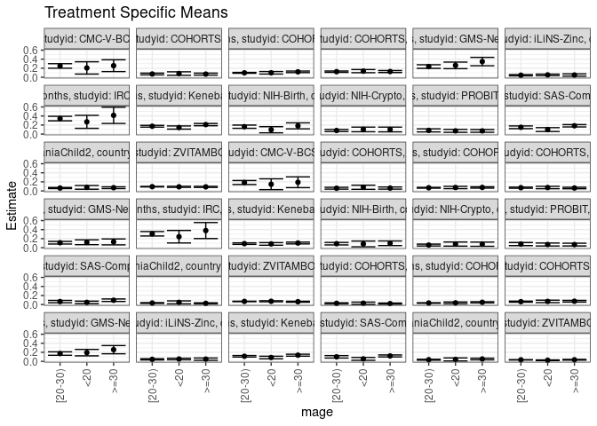

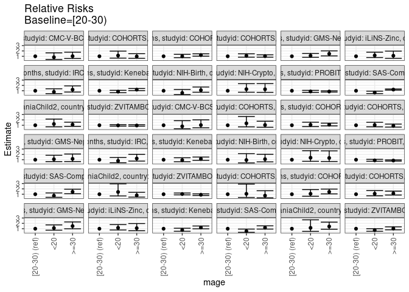

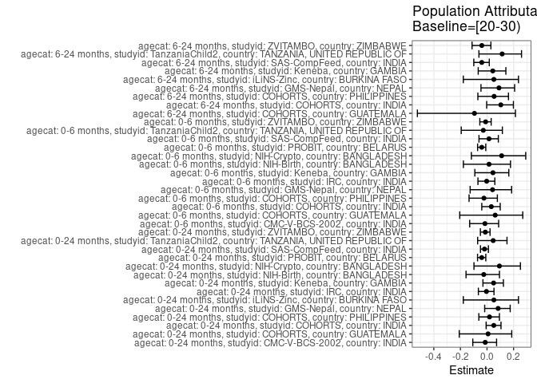

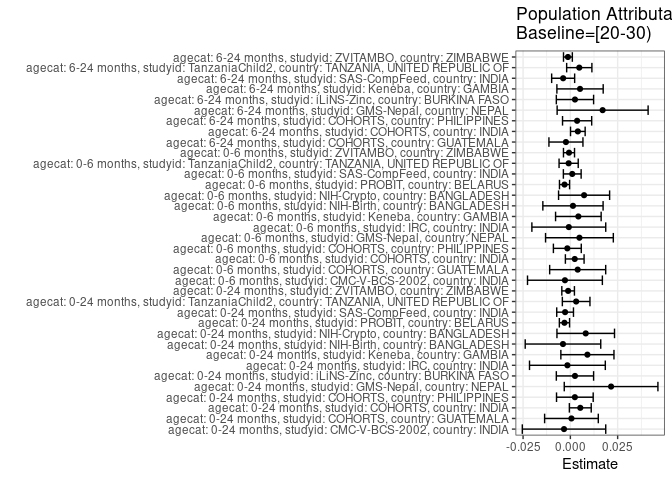

## Results Table

### Parameter: TSM

| agecat | studyid | country | intervention_level | baseline_level | estimate | ci_lower | ci_upper |
| --- | --- | --- | --- | --- | --- | --- | --- |
| 0-24 months | CMC-V-BCS-2002 | INDIA | [20-30) | NA | 0.2500000 | 0.2006047 | 0.2993953 |
| 0-24 months | CMC-V-BCS-2002 | INDIA | <20 | NA | 0.2058824 | 0.0697869 | 0.3419778 |
| 0-24 months | CMC-V-BCS-2002 | INDIA | >=30 | NA | 0.2558140 | 0.1252270 | 0.3864009 |
| 0-24 months | COHORTS | GUATEMALA | [20-30) | NA | 0.0717557 | 0.0519838 | 0.0915276 |
| 0-24 months | COHORTS | GUATEMALA | <20 | NA | 0.0816327 | 0.0432865 | 0.1199788 |
| 0-24 months | COHORTS | GUATEMALA | >=30 | NA | 0.0693878 | 0.0468797 | 0.0918958 |
| 0-24 months | COHORTS | INDIA | [20-30) | NA | 0.0978593 | 0.0881485 | 0.1075702 |
| 0-24 months | COHORTS | INDIA | <20 | NA | 0.0985915 | 0.0702799 | 0.1269032 |
| 0-24 months | COHORTS | INDIA | >=30 | NA | 0.1193448 | 0.1015968 | 0.1370928 |
| 0-24 months | COHORTS | PHILIPPINES | [20-30) | NA | 0.1230769 | 0.1079812 | 0.1381726 |
| 0-24 months | COHORTS | PHILIPPINES | <20 | NA | 0.1352785 | 0.1007481 | 0.1698089 |
| 0-24 months | COHORTS | PHILIPPINES | >=30 | NA | 0.1261792 | 0.1038267 | 0.1485318 |
| 0-24 months | GMS-Nepal | NEPAL | [20-30) | NA | 0.2364865 | 0.1969330 | 0.2760400 |
| 0-24 months | GMS-Nepal | NEPAL | <20 | NA | 0.2624113 | 0.1897416 | 0.3350811 |
| 0-24 months | GMS-Nepal | NEPAL | >=30 | NA | 0.3465347 | 0.2536618 | 0.4394075 |
| 0-24 months | iLiNS-Zinc | BURKINA FASO | [20-30) | NA | 0.0447504 | 0.0314082 | 0.0580927 |
| 0-24 months | iLiNS-Zinc | BURKINA FASO | <20 | NA | 0.0521092 | 0.0351837 | 0.0690347 |
| 0-24 months | iLiNS-Zinc | BURKINA FASO | >=30 | NA | 0.0493708 | 0.0237741 | 0.0749674 |
| 0-24 months | IRC | INDIA | [20-30) | NA | 0.3430233 | 0.2927964 | 0.3932501 |
| 0-24 months | IRC | INDIA | <20 | NA | 0.2702703 | 0.1269995 | 0.4135411 |
| 0-24 months | IRC | INDIA | >=30 | NA | 0.4137931 | 0.2343212 | 0.5932650 |
| 0-24 months | Keneba | GAMBIA | [20-30) | NA | 0.1732502 | 0.1537196 | 0.1927807 |
| 0-24 months | Keneba | GAMBIA | <20 | NA | 0.1446701 | 0.1099299 | 0.1794102 |
| 0-24 months | Keneba | GAMBIA | >=30 | NA | 0.2093476 | 0.1844610 | 0.2342342 |
| 0-24 months | NIH-Birth | BANGLADESH | [20-30) | NA | 0.1630695 | 0.1275833 | 0.1985558 |
| 0-24 months | NIH-Birth | BANGLADESH | <20 | NA | 0.0958904 | 0.0282924 | 0.1634885 |
| 0-24 months | NIH-Birth | BANGLADESH | >=30 | NA | 0.1818182 | 0.1159684 | 0.2476679 |
| 0-24 months | NIH-Crypto | BANGLADESH | [20-30) | NA | 0.0789474 | 0.0551526 | 0.1027422 |
| 0-24 months | NIH-Crypto | BANGLADESH | <20 | NA | 0.1029412 | 0.0518354 | 0.1540470 |
| 0-24 months | NIH-Crypto | BANGLADESH | >=30 | NA | 0.1015625 | 0.0491976 | 0.1539274 |

[output cut: 78 more lines]

### Parameter: E(Y)

| agecat | studyid | country | intervention_level | baseline_level | estimate | ci_lower | ci_upper |
| --- | --- | --- | --- | --- | --- | --- | --- |
| 0-24 months | CMC-V-BCS-2002 | INDIA | NA | NA | 0.2466488 | 0.2028447 | 0.2904529 |
| 0-24 months | COHORTS | GUATEMALA | NA | NA | 0.0723341 | 0.0584645 | 0.0862036 |
| 0-24 months | COHORTS | INDIA | NA | NA | 0.1031103 | 0.0949263 | 0.1112943 |
| 0-24 months | COHORTS | PHILIPPINES | NA | NA | 0.1254516 | 0.1136848 | 0.1372183 |
| 0-24 months | GMS-Nepal | NEPAL | NA | NA | 0.2580175 | 0.2252514 | 0.2907836 |
| 0-24 months | iLiNS-Zinc | BURKINA FASO | NA | NA | 0.0471846 | 0.0353428 | 0.0590265 |
| 0-24 months | IRC | INDIA | NA | NA | 0.3414634 | 0.2955068 | 0.3874201 |
| 0-24 months | Keneba | GAMBIA | NA | NA | 0.1822626 | 0.1681211 | 0.1964040 |
| 0-24 months | NIH-Birth | BANGLADESH | NA | NA | 0.1591640 | 0.1303913 | 0.1879367 |
| 0-24 months | NIH-Crypto | BANGLADESH | NA | NA | 0.0870712 | 0.0669870 | 0.1071555 |
| 0-24 months | PROBIT | BELARUS | NA | NA | 0.0784116 | 0.0458146 | 0.1110087 |
| 0-24 months | SAS-CompFeed | INDIA | NA | NA | 0.1473893 | 0.1184132 | 0.1763654 |
| 0-24 months | TanzaniaChild2 | TANZANIA, UNITED REPUBLIC OF | NA | NA | 0.0660774 | 0.0560867 | 0.0760682 |
| 0-24 months | ZVITAMBO | ZIMBABWE | NA | NA | 0.0919615 | 0.0871588 | 0.0967642 |
| 0-6 months | CMC-V-BCS-2002 | INDIA | NA | NA | 0.1820652 | 0.1425842 | 0.2215462 |
| 0-6 months | COHORTS | GUATEMALA | NA | NA | 0.0630292 | 0.0484135 | 0.0776449 |
| 0-6 months | COHORTS | INDIA | NA | NA | 0.0713446 | 0.0642809 | 0.0784082 |
| 0-6 months | COHORTS | PHILIPPINES | NA | NA | 0.0693167 | 0.0602923 | 0.0783411 |
| 0-6 months | GMS-Nepal | NEPAL | NA | NA | 0.1151603 | 0.0912555 | 0.1390652 |
| 0-6 months | IRC | INDIA | NA | NA | 0.3073171 | 0.2626027 | 0.3520314 |
| 0-6 months | Keneba | GAMBIA | NA | NA | 0.0945172 | 0.0829165 | 0.1061178 |
| 0-6 months | NIH-Birth | BANGLADESH | NA | NA | 0.0903226 | 0.0677415 | 0.1129037 |
| 0-6 months | NIH-Crypto | BANGLADESH | NA | NA | 0.0659631 | 0.0482810 | 0.0836451 |
| 0-6 months | PROBIT | BELARUS | NA | NA | 0.0777153 | 0.0450748 | 0.1103558 |
| 0-6 months | SAS-CompFeed | INDIA | NA | NA | 0.0664452 | 0.0425975 | 0.0902929 |
| 0-6 months | TanzaniaChild2 | TANZANIA, UNITED REPUBLIC OF | NA | NA | 0.0328283 | 0.0256620 | 0.0399945 |
| 0-6 months | ZVITAMBO | ZIMBABWE | NA | NA | 0.0685487 | 0.0643349 | 0.0727624 |
| 6-24 months | COHORTS | GUATEMALA | NA | NA | 0.0247321 | 0.0159885 | 0.0334756 |
| 6-24 months | COHORTS | INDIA | NA | NA | 0.0381279 | 0.0327962 | 0.0434596 |
| 6-24 months | COHORTS | PHILIPPINES | NA | NA | 0.0669277 | 0.0576848 | 0.0761707 |
| 6-24 months | GMS-Nepal | NEPAL | NA | NA | 0.1898305 | 0.1581595 | 0.2215015 |
| 6-24 months | iLiNS-Zinc | BURKINA FASO | NA | NA | 0.0471846 | 0.0353428 | 0.0590265 |
| 6-24 months | Keneba | GAMBIA | NA | NA | 0.1178877 | 0.1056970 | 0.1300784 |
| 6-24 months | SAS-CompFeed | INDIA | NA | NA | 0.0964723 | 0.0729872 | 0.1199573 |
| 6-24 months | TanzaniaChild2 | TANZANIA, UNITED REPUBLIC OF | NA | NA | 0.0414378 | 0.0327076 | 0.0501681 |
| 6-24 months | ZVITAMBO | ZIMBABWE | NA | NA | 0.0329039 | 0.0295377 | 0.0362701 |

### Parameter: RR

| agecat | studyid | country | intervention_level | baseline_level | estimate | ci_lower | ci_upper |
| --- | --- | --- | --- | --- | --- | --- | --- |
| 0-24 months | CMC-V-BCS-2002 | INDIA | [20-30) | [20-30) | 1.0000000 | 1.0000000 | 1.0000000 |
| 0-24 months | CMC-V-BCS-2002 | INDIA | <20 | [20-30) | 0.8235294 | 0.4130909 | 1.6417711 |
| 0-24 months | CMC-V-BCS-2002 | INDIA | >=30 | [20-30) | 1.0232558 | 0.5919164 | 1.7689196 |
| 0-24 months | COHORTS | GUATEMALA | [20-30) | [20-30) | 1.0000000 | 1.0000000 | 1.0000000 |
| 0-24 months | COHORTS | GUATEMALA | <20 | [20-30) | 1.1376465 | 0.6599236 | 1.9611962 |
| 0-24 months | COHORTS | GUATEMALA | >=30 | [20-30) | 0.9669996 | 0.6318067 | 1.4800226 |
| 0-24 months | COHORTS | INDIA | [20-30) | [20-30) | 1.0000000 | 1.0000000 | 1.0000000 |
| 0-24 months | COHORTS | INDIA | <20 | [20-30) | 1.0074824 | 0.7435134 | 1.3651682 |
| 0-24 months | COHORTS | INDIA | >=30 | [20-30) | 1.2195544 | 1.0199006 | 1.4582920 |
| 0-24 months | COHORTS | PHILIPPINES | [20-30) | [20-30) | 1.0000000 | 1.0000000 | 1.0000000 |
| 0-24 months | COHORTS | PHILIPPINES | <20 | [20-30) | 1.0991379 | 0.8280625 | 1.4589530 |
| 0-24 months | COHORTS | PHILIPPINES | >=30 | [20-30) | 1.0252064 | 0.8264866 | 1.2717062 |
| 0-24 months | GMS-Nepal | NEPAL | [20-30) | [20-30) | 1.0000000 | 1.0000000 | 1.0000000 |
| 0-24 months | GMS-Nepal | NEPAL | <20 | [20-30) | 1.1096251 | 0.8029225 | 1.5334830 |
| 0-24 months | GMS-Nepal | NEPAL | >=30 | [20-30) | 1.4653465 | 1.0684184 | 2.0097374 |
| 0-24 months | iLiNS-Zinc | BURKINA FASO | [20-30) | [20-30) | 1.0000000 | 1.0000000 | 1.0000000 |
| 0-24 months | iLiNS-Zinc | BURKINA FASO | <20 | [20-30) | 1.1644398 | 0.7653943 | 1.7715314 |
| 0-24 months | iLiNS-Zinc | BURKINA FASO | >=30 | [20-30) | 1.1032467 | 0.6206064 | 1.9612323 |
| 0-24 months | IRC | INDIA | [20-30) | [20-30) | 1.0000000 | 1.0000000 | 1.0000000 |
| 0-24 months | IRC | INDIA | <20 | [20-30) | 0.7879066 | 0.4546040 | 1.3655769 |
| 0-24 months | IRC | INDIA | >=30 | [20-30) | 1.2063121 | 0.7632228 | 1.9066372 |
| 0-24 months | Keneba | GAMBIA | [20-30) | [20-30) | 1.0000000 | 1.0000000 | 1.0000000 |
| 0-24 months | Keneba | GAMBIA | <20 | [20-30) | 0.8350355 | 0.6404662 | 1.0887137 |
| 0-24 months | Keneba | GAMBIA | >=30 | [20-30) | 1.2083544 | 1.0257568 | 1.4234567 |
| 0-24 months | NIH-Birth | BANGLADESH | [20-30) | [20-30) | 1.0000000 | 1.0000000 | 1.0000000 |
| 0-24 months | NIH-Birth | BANGLADESH | <20 | [20-30) | 0.5880338 | 0.2811840 | 1.2297419 |
| 0-24 months | NIH-Birth | BANGLADESH | >=30 | [20-30) | 1.1149733 | 0.7307436 | 1.7012334 |
| 0-24 months | NIH-Crypto | BANGLADESH | [20-30) | [20-30) | 1.0000000 | 1.0000000 | 1.0000000 |
| 0-24 months | NIH-Crypto | BANGLADESH | <20 | [20-30) | 1.3039216 | 0.7294904 | 2.3306837 |
| 0-24 months | NIH-Crypto | BANGLADESH | >=30 | [20-30) | 1.2864583 | 0.7079846 | 2.3375861 |

[output cut: 78 more lines]

### Parameter: PAR

| agecat | studyid | country | intervention_level | baseline_level | estimate | ci_lower | ci_upper |
| --- | --- | --- | --- | --- | --- | --- | --- |
| 0-24 months | CMC-V-BCS-2002 | INDIA | [20-30) | NA | -0.0033512 | -0.0254025 | 0.0187001 |
| 0-24 months | COHORTS | GUATEMALA | [20-30) | NA | 0.0005784 | -0.0136133 | 0.0147700 |
| 0-24 months | COHORTS | INDIA | [20-30) | NA | 0.0052509 | -0.0005283 | 0.0110302 |
| 0-24 months | COHORTS | PHILIPPINES | [20-30) | NA | 0.0023746 | -0.0073170 | 0.0120663 |
| 0-24 months | GMS-Nepal | NEPAL | [20-30) | NA | 0.0215310 | -0.0032266 | 0.0462886 |
| 0-24 months | iLiNS-Zinc | BURKINA FASO | [20-30) | NA | 0.0024342 | -0.0074188 | 0.0122872 |
| 0-24 months | IRC | INDIA | [20-30) | NA | -0.0015598 | -0.0215967 | 0.0184770 |
| 0-24 months | Keneba | GAMBIA | [20-30) | NA | 0.0090124 | -0.0050250 | 0.0230498 |
| 0-24 months | NIH-Birth | BANGLADESH | [20-30) | NA | -0.0039056 | -0.0238720 | 0.0160609 |
| 0-24 months | NIH-Crypto | BANGLADESH | [20-30) | NA | 0.0081239 | -0.0070938 | 0.0233415 |
| 0-24 months | PROBIT | BELARUS | [20-30) | NA | -0.0031217 | -0.0058202 | -0.0004232 |
| 0-24 months | SAS-CompFeed | INDIA | [20-30) | NA | -0.0027843 | -0.0072140 | 0.0016453 |
| 0-24 months | TanzaniaChild2 | TANZANIA, UNITED REPUBLIC OF | [20-30) | NA | 0.0030603 | -0.0042369 | 0.0103574 |
| 0-24 months | ZVITAMBO | ZIMBABWE | [20-30) | NA | -0.0011837 | -0.0045159 | 0.0021486 |
| 0-6 months | CMC-V-BCS-2002 | INDIA | [20-30) | NA | -0.0028663 | -0.0226565 | 0.0169239 |
| 0-6 months | COHORTS | GUATEMALA | [20-30) | NA | 0.0038689 | -0.0109427 | 0.0186804 |
| 0-6 months | COHORTS | INDIA | [20-30) | NA | 0.0023093 | -0.0026326 | 0.0072513 |
| 0-6 months | COHORTS | PHILIPPINES | [20-30) | NA | -0.0016014 | -0.0089687 | 0.0057659 |
| 0-6 months | GMS-Nepal | NEPAL | [20-30) | NA | 0.0048000 | -0.0131150 | 0.0227150 |
| 0-6 months | IRC | INDIA | [20-30) | NA | -0.0008225 | -0.0203468 | 0.0187019 |
| 0-6 months | Keneba | GAMBIA | [20-30) | NA | 0.0042276 | -0.0078197 | 0.0162748 |
| 0-6 months | NIH-Birth | BANGLADESH | [20-30) | NA | 0.0013803 | -0.0145456 | 0.0173061 |
| 0-6 months | NIH-Crypto | BANGLADESH | [20-30) | NA | 0.0072586 | -0.0062358 | 0.0207530 |
| 0-6 months | PROBIT | BELARUS | [20-30) | NA | -0.0030828 | -0.0057569 | -0.0004087 |
| 0-6 months | SAS-CompFeed | INDIA | [20-30) | NA | 0.0010002 | -0.0036966 | 0.0056969 |
| 0-6 months | TanzaniaChild2 | TANZANIA, UNITED REPUBLIC OF | [20-30) | NA | -0.0009082 | -0.0059724 | 0.0041560 |
| 0-6 months | ZVITAMBO | ZIMBABWE | [20-30) | NA | -0.0007210 | -0.0036433 | 0.0022013 |
| 6-24 months | COHORTS | GUATEMALA | [20-30) | NA | -0.0023407 | -0.0113312 | 0.0066498 |
| 6-24 months | COHORTS | INDIA | [20-30) | NA | 0.0039526 | 0.0000865 | 0.0078186 |
| 6-24 months | COHORTS | PHILIPPINES | [20-30) | NA | 0.0035685 | -0.0041369 | 0.0112739 |
| 6-24 months | GMS-Nepal | NEPAL | [20-30) | NA | 0.0170556 | -0.0069955 | 0.0411068 |
| 6-24 months | iLiNS-Zinc | BURKINA FASO | [20-30) | NA | 0.0024342 | -0.0074188 | 0.0122872 |
| 6-24 months | Keneba | GAMBIA | [20-30) | NA | 0.0051170 | -0.0071218 | 0.0173558 |
| 6-24 months | SAS-CompFeed | INDIA | [20-30) | NA | -0.0038115 | -0.0098898 | 0.0022667 |
| 6-24 months | TanzaniaChild2 | TANZANIA, UNITED REPUBLIC OF | [20-30) | NA | 0.0047125 | -0.0019571 | 0.0113821 |
| 6-24 months | ZVITAMBO | ZIMBABWE | [20-30) | NA | -0.0012913 | -0.0036253 | 0.0010428 |

### Parameter: PAF

| agecat | studyid | country | intervention_level | baseline_level | estimate | ci_lower | ci_upper |
| --- | --- | --- | --- | --- | --- | --- | --- |
| 0-24 months | CMC-V-BCS-2002 | INDIA | [20-30) | NA | -0.0135870 | -0.1070401 | 0.0719771 |
| 0-24 months | COHORTS | GUATEMALA | [20-30) | NA | 0.0079956 | -0.2089401 | 0.1860037 |
| 0-24 months | COHORTS | INDIA | [20-30) | NA | 0.0509255 | -0.0066908 | 0.1052443 |
| 0-24 months | COHORTS | PHILIPPINES | [20-30) | NA | 0.0189287 | -0.0614325 | 0.0932058 |
| 0-24 months | GMS-Nepal | NEPAL | [20-30) | NA | 0.0834479 | -0.0174720 | 0.1743578 |
| 0-24 months | iLiNS-Zinc | BURKINA FASO | [20-30) | NA | 0.0515892 | -0.1783814 | 0.2366792 |
| 0-24 months | IRC | INDIA | [20-30) | NA | -0.0045681 | -0.0649954 | 0.0524305 |
| 0-24 months | Keneba | GAMBIA | [20-30) | NA | 0.0494473 | -0.0307168 | 0.1233767 |
| 0-24 months | NIH-Birth | BANGLADESH | [20-30) | NA | -0.0245379 | -0.1579328 | 0.0934897 |
| 0-24 months | NIH-Crypto | BANGLADESH | [20-30) | NA | 0.0933014 | -0.0981199 | 0.2513547 |
| 0-24 months | PROBIT | BELARUS | [20-30) | NA | -0.0398122 | -0.0712524 | -0.0092947 |
| 0-24 months | SAS-CompFeed | INDIA | [20-30) | NA | -0.0188909 | -0.0491895 | 0.0105327 |
| 0-24 months | TanzaniaChild2 | TANZANIA, UNITED REPUBLIC OF | [20-30) | NA | 0.0463132 | -0.0705524 | 0.1504212 |
| 0-24 months | ZVITAMBO | ZIMBABWE | [20-30) | NA | -0.0128712 | -0.0497577 | 0.0227191 |
| 0-6 months | CMC-V-BCS-2002 | INDIA | [20-30) | NA | -0.0157432 | -0.1304383 | 0.0873149 |
| 0-6 months | COHORTS | GUATEMALA | [20-30) | NA | 0.0613820 | -0.2051629 | 0.2689754 |
| 0-6 months | COHORTS | INDIA | [20-30) | NA | 0.0323687 | -0.0393716 | 0.0991573 |
| 0-6 months | COHORTS | PHILIPPINES | [20-30) | NA | -0.0231026 | -0.1350646 | 0.0778154 |
| 0-6 months | GMS-Nepal | NEPAL | [20-30) | NA | 0.0416809 | -0.1270107 | 0.1851227 |
| 0-6 months | IRC | INDIA | [20-30) | NA | -0.0026763 | -0.0682637 | 0.0588843 |
| 0-6 months | Keneba | GAMBIA | [20-30) | NA | 0.0447281 | -0.0915192 | 0.1639686 |
| 0-6 months | NIH-Birth | BANGLADESH | [20-30) | NA | 0.0152816 | -0.1777722 | 0.1766911 |
| 0-6 months | NIH-Crypto | BANGLADESH | [20-30) | NA | 0.1100405 | -0.1176092 | 0.2913194 |
| 0-6 months | PROBIT | BELARUS | [20-30) | NA | -0.0396677 | -0.0708261 | -0.0094159 |
| 0-6 months | SAS-CompFeed | INDIA | [20-30) | NA | 0.0150524 | -0.0603904 | 0.0851277 |
| 0-6 months | TanzaniaChild2 | TANZANIA, UNITED REPUBLIC OF | [20-30) | NA | -0.0276649 | -0.1939816 | 0.1154846 |
| 0-6 months | ZVITAMBO | ZIMBABWE | [20-30) | NA | -0.0105178 | -0.0540561 | 0.0312223 |
| 6-24 months | COHORTS | GUATEMALA | [20-30) | NA | -0.0946418 | -0.5237626 | 0.2136303 |
| 6-24 months | COHORTS | INDIA | [20-30) | NA | 0.1036660 | -0.0026060 | 0.1986736 |
| 6-24 months | COHORTS | PHILIPPINES | [20-30) | NA | 0.0533187 | -0.0688745 | 0.1615428 |
| 6-24 months | GMS-Nepal | NEPAL | [20-30) | NA | 0.0898467 | -0.0455084 | 0.2076782 |
| 6-24 months | iLiNS-Zinc | BURKINA FASO | [20-30) | NA | 0.0515892 | -0.1783814 | 0.2366792 |
| 6-24 months | Keneba | GAMBIA | [20-30) | NA | 0.0434054 | -0.0661746 | 0.1417230 |
| 6-24 months | SAS-CompFeed | INDIA | [20-30) | NA | -0.0395092 | -0.0993964 | 0.0171158 |
| 6-24 months | TanzaniaChild2 | TANZANIA, UNITED REPUBLIC OF | [20-30) | NA | 0.1137250 | -0.0607877 | 0.2595282 |
| 6-24 months | ZVITAMBO | ZIMBABWE | [20-30) | NA | -0.0392440 | -0.1125433 | 0.0292261 |